Load a few plot helpers.

```r
color.ramp <-function(palette="Spectral", reverse=TRUE, sample=FALSE)
{
  library(RColorBrewer)
  n <- brewer.pal.info[palette,]$maxcolors
  pal <- brewer.pal(n, palette)
  if (reverse) pal <- rev(pal)
  if (sample) pal <- sample(pal)
  return(colorRampPalette(pal))
}

set.spplot.colors <- function(ncol = 100, palette = "Spectral", reverse = TRUE, sample = FALSE)
{
  library(lattice)
  pal <- color.ramp(palette, reverse, sample)(ncol)
  trellis.par.set(regions = list(col = pal))
}
```

# Geospatial Data Analysis in `R`

## Raster Data Sources

```r
library(raster)
library(rasterVis)
```

### Raster Visualization

```r
r <- raster("ncrast/elev_lid792_1m.tif")
```

#### Visualizing Values

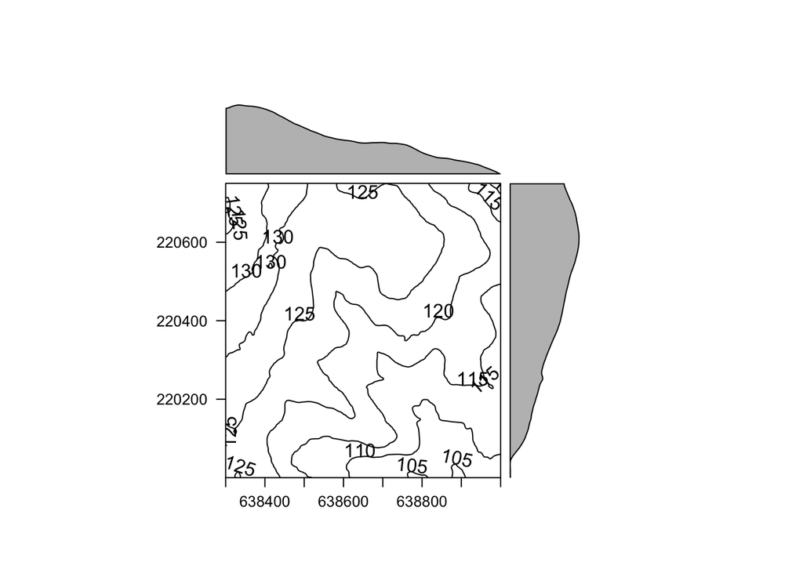

```r
contourplot(r)
```

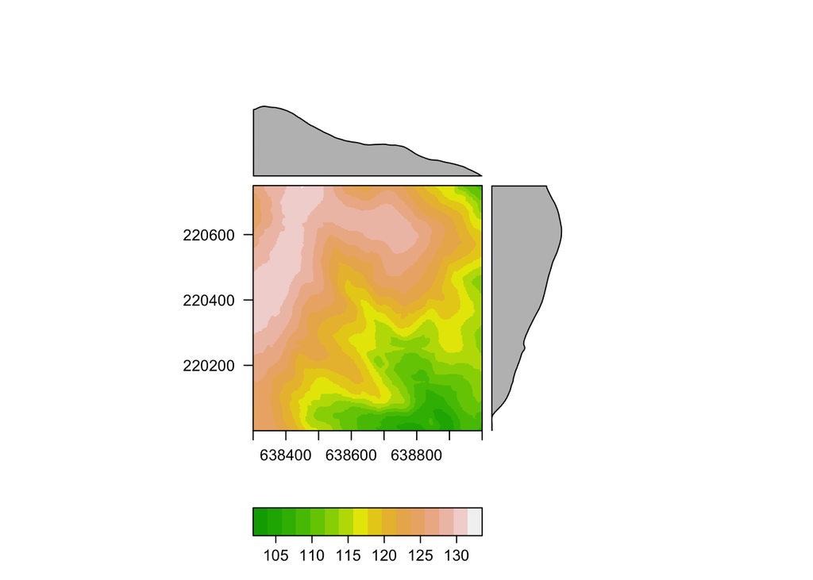

```r
levelplot(r, col.regions=terrain.colors)
```

#### Visualizing How Values are Changing

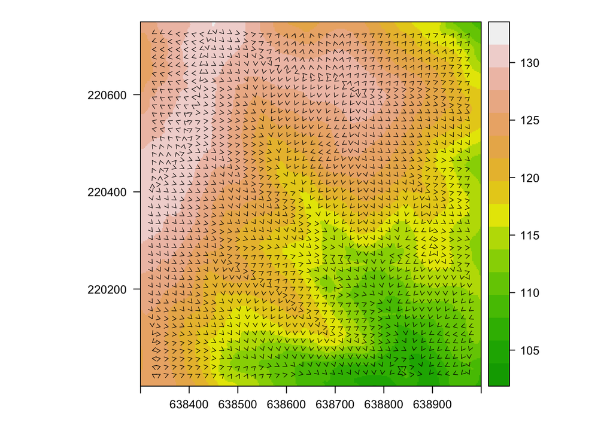

```r
vectorplot(r, col.regions=terrain.colors)
```

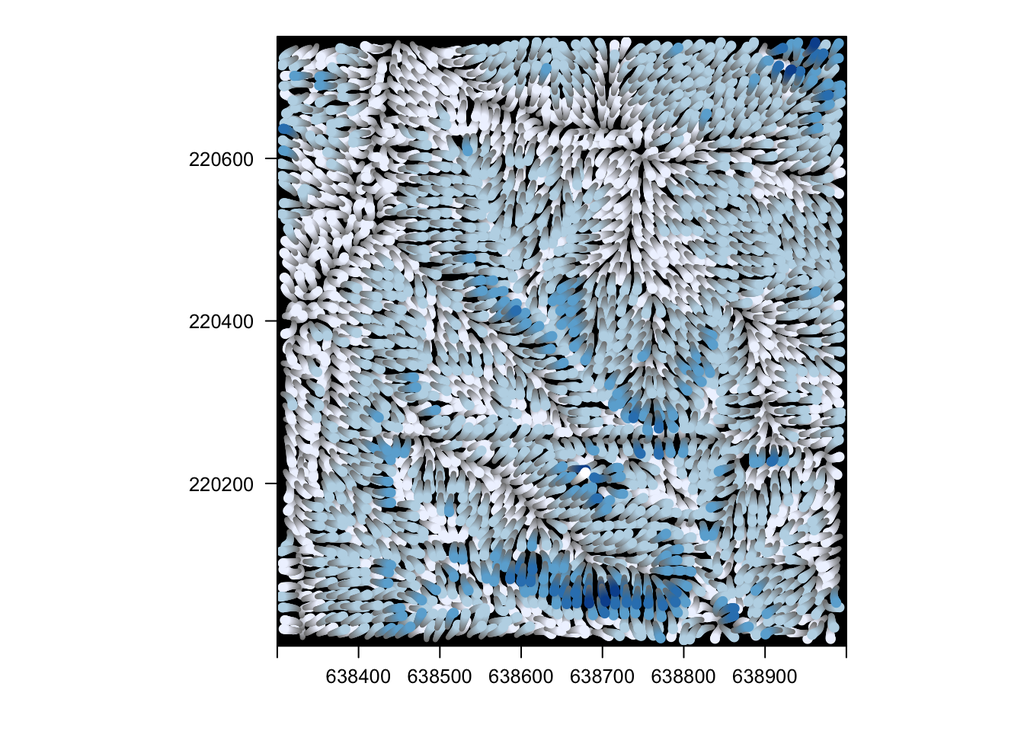

```r
streamplot(r)
```

#### Interactive 3D Visualization

Mouse wheel to zoom, click and drag to rotate. This code will not be run when generating the html. Try it in R.

```r
library("rasterVis")
r <- raster("ncrast/elev_lid792_1m.tif")
plot3D(r)
```

### Working With Raster Values

#### Convert to Matrix

```r
m <- as.matrix(r)
m[1:3, 1:3]         # first 3 rows and columns
```

```
##          [,1]     [,2]     [,3]
## [1,] 126.3382 126.3382 126.3415
## [2,] 126.3070 126.3049 126.3060
## [3,] 126.2784 126.2743 126.2735
```

#### Aggregate

```r
r.mean <- aggregate(r, fact=10, fun=mean)
r.max <- aggregate(r, fact=10, fun=max)
r.min <- aggregate(r, fact=10, fun=min)
```

Dimensions changed:

```r
dim(r)
dim(r.mean)
```

```
## [1] 750 700   1
## [1] 75 70  1
```

Spatial extent unchanged:

```r
extent(r)
extent(r.mean)
```

```
## class      : Extent
## xmin       : 638300
## xmax       : 639000
## ymin       : 220000
## ymax       : 220750
## class      : Extent
## xmin       : 638300
## xmax       : 639000
## ymin       : 220000
## ymax       : 220750
```

#### Disaggregate

Either repeats values or linearly interpolates them.

```r
r.mean <- disaggregate(r.mean, fact=10)
r.mean.interp <- disaggregate(r.max, fact=10, method='bilinear')
```

Raster layers must have identical spatial extent and resolution to be stacked.

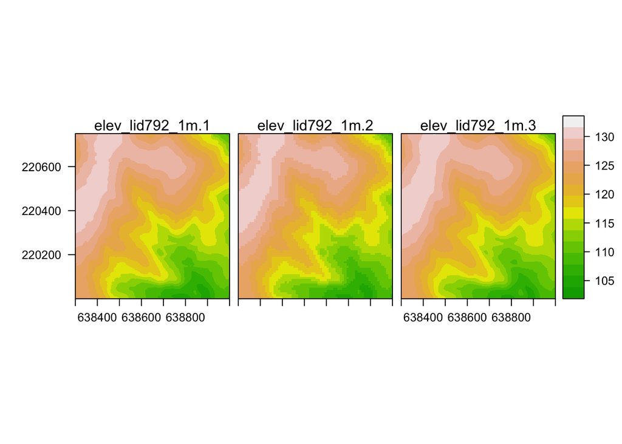

```r
levelplot(stack(r, r.mean, r.mean.interp), col.regions=terrain.colors)
```

### Raster to Vector Conversion

#### Raster to XYZ Points

The Z coordinate is the raster value.

```r
pts <- rasterToPoints(r)
head(pts)
```

```
##             x        y elev_lid792_1m
## [1,] 638300.5 220749.5       126.3382
## [2,] 638301.5 220749.5       126.3382
## [3,] 638302.5 220749.5       126.3415
## [4,] 638303.5 220749.5       126.3494
## [5,] 638304.5 220749.5       126.3635
## [6,] 638305.5 220749.5       126.3852
```

#### Raster to `SpatialPoints`

```r
sp.pts <- rasterToPoints(r, spatial=T)
summary(sp.pts)
```

```
## Object of class SpatialPointsDataFrame
## Coordinates:
##        min      max
## x 638300.5 638999.5
## y 220000.5 220749.5
## Is projected: TRUE
## proj4string :
## [+proj=lcc +lat_1=36.16666666666666 +lat_2=34.33333333333334
## +lat_0=33.75 +lon_0=-79 +x_0=609601.22 +y_0=0 +datum=NAD83
## +units=m +no_defs +ellps=GRS80 +towgs84=0,0,0]
## Number of points: 525000
## Data attributes:
##  elev_lid792_1m
##  Min.   :103.8
##  1st Qu.:115.8
##  Median :121.3
##  Mean   :120.8
##  3rd Qu.:126.5
##  Max.   :131.6
```

#### Raster to `SpatialPolygons`

The `raster` package provides `rasterToPolygons` but performance is unacceptable for large rasters. Use the command line utility `gdal_polygonize.py` instead. In the “tools” menu above in RStudio, you will see a “shell” option. You can use that to enter these commands. (Your directory probably already has these files, so you may not need to do this.)

```
cd Exercises
gdal_polygonize.py ncrast/zipcodes.tif -f "ESRI Shapefile" extra zipcodes zipnum
```

Now read in the shapefile and convert the zipnum attribute to a factor:

```r
library(rgdal)
```

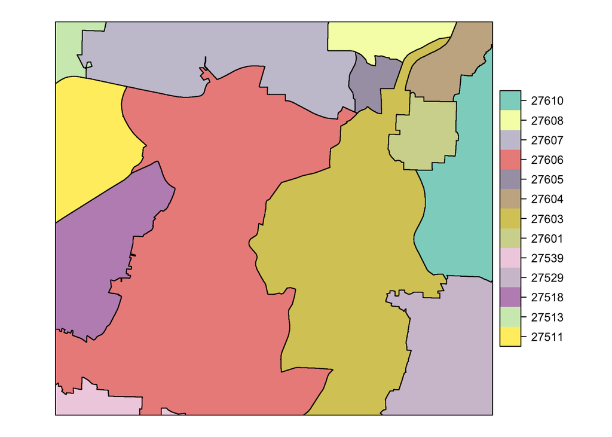

```r
zipcodes <- readOGR(dsn="extra", layer="zipcodes", verbose=F)
zipcodes$zipnum <- factor(zipcodes$zipnum)
spplot(zipcodes, col.regions=color.ramp("Set3")(nlevels(zipcodes$zipnum)))
```

#### Activity: Reproject a Raster

Use the `projectRaster` function to reproject the *elev_state_500m.tif* elevation map to longitude/latitude coordinates. Call `projectRaster` with a raster object and a named crs string `crs=+proj=longlat`. Then usen `levelplot` to visualize the result.

Functions: `raster`, `projectRaster`, `levelplot`

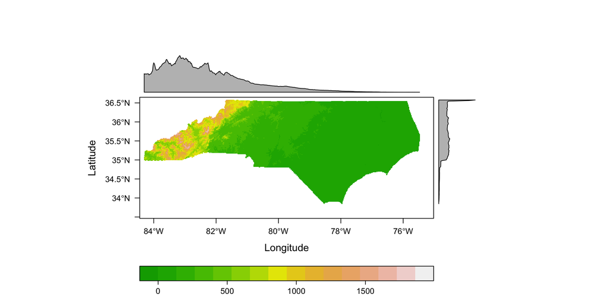

#### Activity: Calculate NDVI

Use the near infrared (*lsat7_2002_40.tif*) and visible (*lsat7_2002_30.tif*) LSAT imagery to calculat NDVI. NDVI is defined as (NIR - VIS)/(NIR + VIS). Use `levelplot` to visualize the result.

Functions: `raster`, `levelplot`, `rev`, `terrain.colors`

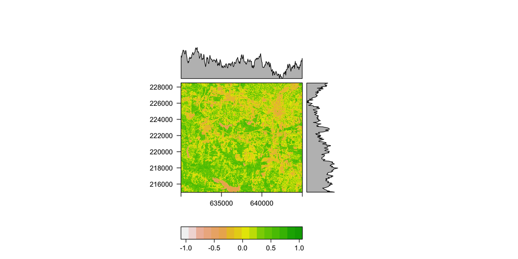